# Reproducible Research: Peer Assessment 1

Before starting the analysis set up all global options for the code chunks

```r
opts_chunk$set(fig.width = 10, fig.height = 6)
```

## Loading and preprocessing the data

```r
data <- read.csv("activity.csv")
```

## What is mean total number of steps taken per day?

Group steps by date for which they were recorded:

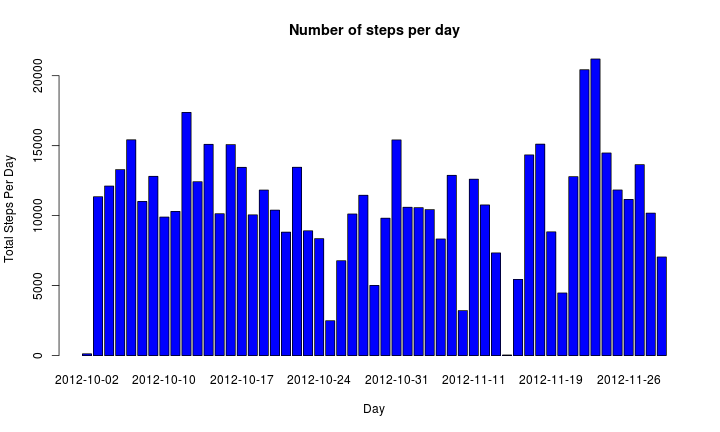

```r
per_day <- aggregate(steps ~ date, data, sum)
barplot(per_day$steps, main = "Number of steps per day", xlab = "Day", ylab = "Total Steps Per Day",
    names.arg = per_day$date, col = "blue", )
```

To gain some extra perspective into the way one should understand the above we can take a look at the histogram of steps:

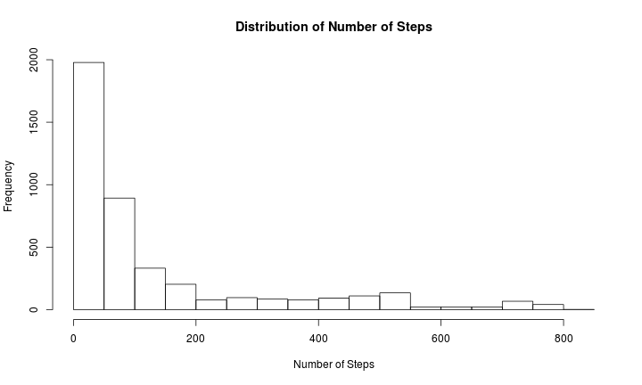

```r
hist(subset(data, steps > 0)$steps, breaks = 25, xlab = "Number of Steps", main = "Distribution of Number of Steps")
```

In order to understand total number of steps a little bit more one could calculate the mean and median of the series:

```r
mean_steps <- mean(per_day$steps)
median_steps <- median(per_day$steps)
```

Giving the following results:

- **Mean**: 1.0766 × 10<sup>4</sup>
- **Median**: 10765

## What is the average daily activity pattern?

Let's look at the line plot showing daily activity across all dates:

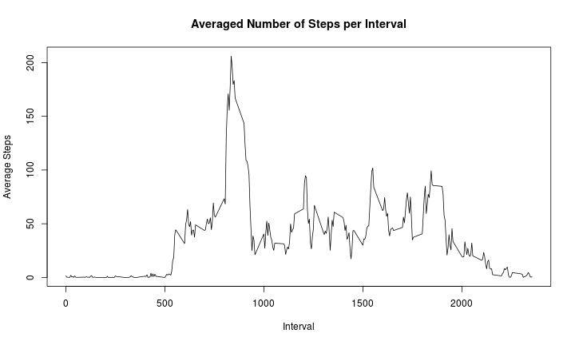

```r
per_interval <- aggregate(steps ~ interval, data, mean)
x <- per_interval$interval
y <- per_interval$steps
plot(x, y, type = "l", xlab = "Interval", ylab = "Average Steps", main = "Averaged Number of Steps per Interval")
```

it's clearly visible that the maximum appears at:

```r
subset(per_interval, steps == max(y))$interval
```

```
## [1] 835
```

## Imputing missing values

```r
number_of_nas <- sum(is.na(data$steps))
```

Total number of NAs is 2304.

```r
library(zoo)
new_data <- data
new_data$steps <- na.aggregate(data$steps, by = "date", FUN = mean)
```

Let's see whether our strategy for filling up the NAs has any serious impact on the data. First let's have a look at the distribution of total number of steps for each day

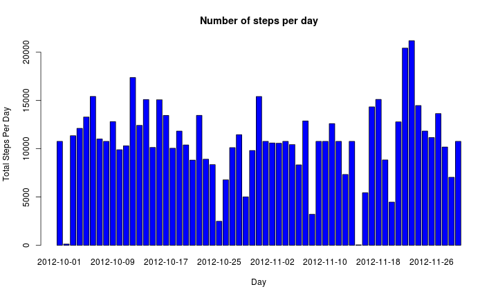

```r
new_per_day <- aggregate(steps ~ date, new_data, sum)
barplot(new_per_day$steps, main = "Number of steps per day", xlab = "Day", ylab = "Total Steps Per Day",
    names.arg = new_per_day$date, col = "blue", )
```

Also as before let's calculate mean and median for the new data set:

```r
new_mean_steps <- mean(new_per_day$steps)
new_median_steps <- median(new_per_day$steps)
```

Giving the following results:

- **Mean**: 1.0766 × 10<sup>4</sup>
- **Median**: 1.0766 × 10<sup>4</sup>

One can clearly see that the difference is minimal:

- **Mean Diff**: 0
- **Median Diff**: 1.1887

## Are there differences in activity patterns between weekdays and weekends?

Before answering the question of whether there's any difference bettwen weekend and weekday behaviour one needs to create new factor variable:

```r
new_data$day_type <- weekdays(as.POSIXlt(new_data$date, format = "%Y-%m-%d"))
weekend <- c("Saturday", "Sunday")
weekdays <- c("Monday", "Tuesday", "Wednesday", "Thursday", "Friday")
new_data[new_data$day_type %in% weekend, ]$day_type <- "weekend"
new_data[new_data$day_type %in% weekdays, ]$day_type <- "weekday"
new_data$day_type <- factor(new_data$day_type)
```

Finally let's have a look at the difference between weekend and weekday behaviour:

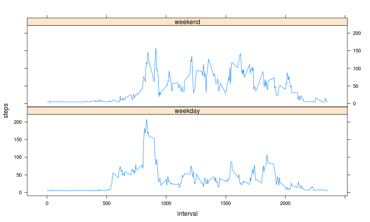

```r
library(lattice)
new_per_interval_weekend <- aggregate(steps ~ interval, subset(new_data, day_type ==
    "weekend"), mean)
new_per_interval_weekend$day_type <- "weekend"

new_per_interval_weekday <- aggregate(steps ~ interval, subset(new_data, day_type ==
    "weekday"), mean)
new_per_interval_weekday$day_type <- "weekday"

day_type_data <- rbind(new_per_interval_weekend, new_per_interval_weekday)
xyplot(steps ~ interval | day_type, data = day_type_data, layout = c(1, 2),
    type = "l")
```